# R en OS Weekends

### Transformar y visualizar

Vamos a intercalar transformaciones y visualizaciones para mostrar varios ejemplos y como funcionan las librerías. Recordad que empezamos con datos limpios y estructurados.

```r
# Cargamos un paquete que incluye los datos que vamos a utilizar
library(nycflights13)
# Guardo los datos en una variable
flights <- flights
# Voy a ver la estructura básica de mi data frame
head(flights)
```

| year | month | day | dep_time | sched_dep_time | dep_delay | arr_time | sched_arr_time | arr_delay | carrier | flight | tailnum | origin | dest | air_time | distance | hour | minute | time_hour |
| --- | --- | --- | --- | --- | --- | --- | --- | --- | --- | --- | --- | --- | --- | --- | --- | --- | --- | --- |
| 2013 | 1 | 1 | 517 | 515 | 2 | 830 | 819 | 11 | UA | 1545 | N14228 | EWR | IAH | 227 | 1400 | 5 | 15 | 2013-01-01 05:00:00 |
| 2013 | 1 | 1 | 533 | 529 | 4 | 850 | 830 | 20 | UA | 1714 | N24211 | LGA | IAH | 227 | 1416 | 5 | 29 | 2013-01-01 05:00:00 |
| 2013 | 1 | 1 | 542 | 540 | 2 | 923 | 850 | 33 | AA | 1141 | N619AA | JFK | MIA | 160 | 1089 | 5 | 40 | 2013-01-01 05:00:00 |
| 2013 | 1 | 1 | 544 | 545 | -1 | 1004 | 1022 | -18 | B6 | 725 | N804JB | JFK | BQN | 183 | 1576 | 5 | 45 | 2013-01-01 05:00:00 |
| 2013 | 1 | 1 | 554 | 600 | -6 | 812 | 837 | -25 | DL | 461 | N668DN | LGA | ATL | 116 | 762 | 6 | 0 | 2013-01-01 06:00:00 |
| 2013 | 1 | 1 | 554 | 558 | -4 | 740 | 728 | 12 | UA | 1696 | N39463 | EWR | ORD | 150 | 719 | 5 | 58 | 2013-01-01 05:00:00 |

```r
str(flights)
```

```
Classes ‘tbl_df’, ‘tbl’ and 'data.frame':   336776 obs. of  19 variables:
 $ year          : int  2013 2013 2013 2013 2013 2013 2013 2013 2013 2013 ...
 $ month         : int  1 1 1 1 1 1 1 1 1 1 ...
 $ day           : int  1 1 1 1 1 1 1 1 1 1 ...
 $ dep_time      : int  517 533 542 544 554 554 555 557 557 558 ...
 $ sched_dep_time: int  515 529 540 545 600 558 600 600 600 600 ...
 $ dep_delay     : num  2 4 2 -1 -6 -4 -5 -3 -3 -2 ...
 $ arr_time      : int  830 850 923 1004 812 740 913 709 838 753 ...
 $ sched_arr_time: int  819 830 850 1022 837 728 854 723 846 745 ...
 $ arr_delay     : num  11 20 33 -18 -25 12 19 -14 -8 8 ...
 $ carrier       : chr  "UA" "UA" "AA" "B6" ...
 $ flight        : int  1545 1714 1141 725 461 1696 507 5708 79 301 ...
 $ tailnum       : chr  "N14228" "N24211" "N619AA" "N804JB" ...
 $ origin        : chr  "EWR" "LGA" "JFK" "JFK" ...
 $ dest          : chr  "IAH" "IAH" "MIA" "BQN" ...
 $ air_time      : num  227 227 160 183 116 150 158 53 140 138 ...
 $ distance      : num  1400 1416 1089 1576 762 ...
 $ hour          : num  5 5 5 5 6 5 6 6 6 6 ...
 $ minute        : num  15 29 40 45 0 58 0 0 0 0 ...
 $ time_hour     : POSIXct, format: "2013-01-01 05:00:00" "2013-01-01 05:00:00" "2013-01-01 05:00:00" "2013-01-01 05:00:00" ...
```

```r
nrow(flights)
```

```
[1] 336776
```

```r
ncol(flights)
```

```
[1] 19
```

¿Qué fechas tengo en el Data Frame?

```r
unique(flights$month)
```

```
 [1]  1 10 11 12  2  3  4  5  6  7  8  9
```

```r
unique(flights$day)
```

```
 [1]  1  2  3  4  5  6  7  8  9 10 11 12 13 14 15 16 17 18 19 20 21 22 23 24 25 26 27 28 29 30 31
```

Genial. Parece que tengo todo el año de 2013 así que voy a tomar enero y a explorar mis datos. Filtrar con [*dplyr*](http://dplyr.tidyverse.org/) es muy sencillo, solo tengo que pensarlo.

```r
flights_yan <- flights %>% # Llamo al data frame que voy a utilizar
  filter(month == 1) # Filtro el mes. Dplyr funciona por capas así que cada vez que incluyo %>% y hago una operación trabajo sobre el resultado que tengo justo anteriormente. Me ahorro almacenar cada operación en una variable.
nrow(flights_yan)
```

```
[1] 27004
```

Voy a ver los vuelos en enero, en el eje x voy a llamar a la `fecha y hora` y en el eje y voy a transformarlo con ggplot directamente en un conteo de los vuelos. Esta transformación la hago directamente con ggplot, aunque también la podría haber realizado en el data frame directamente.

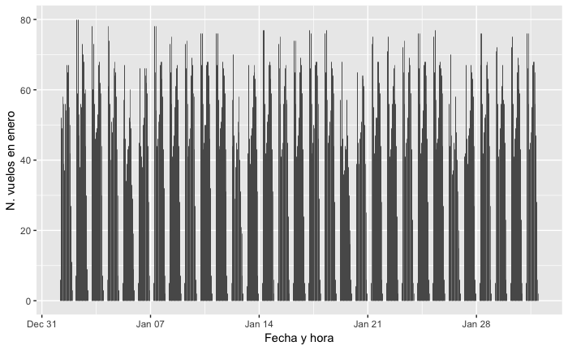

```r
ggplot(data = flights_yan, aes(x = time_hour)) +
  geom_bar() +
  labs(x = 'Fecha y hora', y = 'N. vuelos en enero')
```

Parece que los vuelos se cortan de madrugada… Voy a ver si es verdad, para eso voy a darle color a los datos, así veo si los vuelos salen después o antes de las 7 de la mañana.

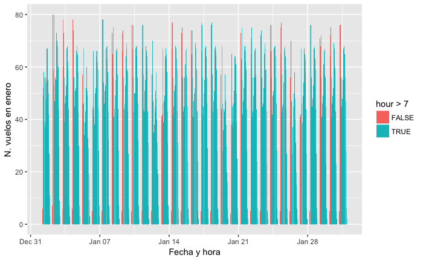

```r
ggplot(data = flights_yan, aes(x = time_hour, fill = hour > 7)) +
  geom_bar() +
  labs(x = 'Fecha y hora', y = 'N. vuelos en enero')
```

Si alguna vez no te acuerdas de alguna función puedes visitar la ayuda o los [cheatsheets](https://www.rstudio.com/wp-content/uploads/2015/03/ggplot2-cheatsheet.pdf).

Se ve bastante bien que la mayoría de vuelos salen después de las 7, pero si quisiese viajar de madrugada, ¿qué compañía puede ayudarme? Eso lo puedo ver fácilmente con la función de ggplot `facet_wrap` que divide los gráficos por la dimensión que le indique siempre poniendo la misma escala.

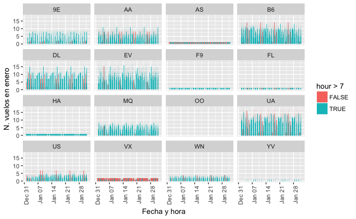

```r
ggplot(data = flights_yan, aes(x = time_hour, fill = hour > 7)) +
  geom_bar() +
  labs(x = 'Fecha y hora', y = 'N. vuelos en enero') +
  facet_wrap(~ carrier) +
  theme(axis.text.x = element_text(angle = 90, hjust = 1)) # Vamos a rotar las etiquetas del eje x para que sea legible.
```

Las aerolíneas que me pueden ayudar son B6 (por la cantidad de vuelos) y VX (por la frecuencia de vuelos) pero no sé cuáles son así que voy a usar el dataset `airlines` que contiene los nombres de las aerolíneas para saberlo. Voy a añadirle la columna de los nombres a `flights` con un left join.

```r
airlines <- airlines
flights_yan <- left_join(flights_yan, airlines, by = 'carrier')
unique(flights_yan$name)
```

```
 [1] "United Air Lines Inc."       "American Airlines Inc."      "JetBlue Airways"
 [4] "Delta Air Lines Inc."        "ExpressJet Airlines Inc."    "Envoy Air"
 [7] "US Airways Inc."             "Southwest Airlines Co."      "Virgin America"
[10] "AirTran Airways Corporation" "Alaska Airlines Inc."        "Endeavor Air Inc."
[13] "Frontier Airlines Inc."      "Hawaiian Airlines Inc."      "Mesa Airlines Inc."
[16] "SkyWest Airlines Inc."
```

Voy a agrupar por hora porque realmente no me importa el día, solo quiero ver si es de madrugada, y hago un conteo después de agruparlo.

```r
flights_yan_hour <- flights_yan %>%
  group_by(hour, name) %>%
  summarise(count = n())
str(flights_yan_hour)
```

```
Classes ‘grouped_df’, ‘tbl_df’, ‘tbl’ and 'data.frame': 179 obs. of  3 variables:
 $ hour : num  5 5 5 5 6 6 6 6 6 6 ...
 $ name : chr  "American Airlines Inc." "JetBlue Airways" "United Air Lines Inc." "US Airways Inc." ...
 $ count: int  31 32 67 27 30 244 204 26 112 355 ...
 - attr(*, "vars")= chr "hour"
 - attr(*, "drop")= logi TRUE
```

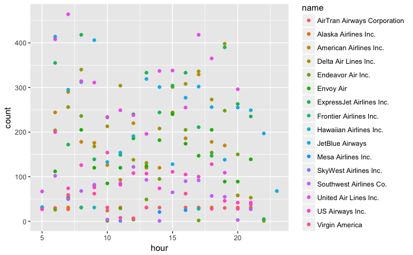

```r
ggplot(data = flights_yan_hour, aes(x = hour, y = count, color = name)) +
  geom_point()
```

### Modelización

Esta es una parte muy interesante del análisis, hay millones de artículos y modelos. Para empezar recomiendo la introducción en el libro [R for Data Science](http://r4ds.had.co.nz/model-basics.html).

### Communicate

Hay varias formas de comunicar en R, la más sencilla y más cómoda es RMarkdown. Además desde el IDE RStudio es muy sencillo crear uno, solo tienes que crear un nuevo archivo y en vez de un script, clickar sobre RMarkdown. Todo el texto plano se hace con la sintaxis de [markdown](https://daringfireball.net/projects/markdown/) y la parte ejecutable de código se hace sobre *`code chunks`*.

Si no sabes a lo que me refiero, ¡bajate esta guía y explóra el código tú mismo!

## Preguntas y respuestas

Si tienes alguna pregunta no dudes en contactarme por [twitter](https://twitter.com/Chucheria), [GitHub](https://github.com/chucheria) o directamente en el Slack de OS Weekends! (@b).

Además, puedes encontrar más material y tutoriales el en [GitHub de RLadies](https://github.com/rladies/)